# Extractive Land Uses and Farm Performance: Evidence of Technology Gaps and Adaptive Efficiency

Francis Tsiboe

Mark Appiah-Twumasi

Antoinette Tsiboe-Darko

Sylvanus Gaku

# Abstract

Extractive land uses contribute to much-needed revenue and employment in developing countries, but they may also compete with agriculture for land, water, labour, and policy attention. This paper examines how gold and bauxite mining, sand winning, and stone quarrying affect crop production technology and efficiency in Ghana. Using four waves of the Ghana Living Standards Survey, matching, and a meta-stochastic frontier framework, we decompose farm performance into technology gaps, technical efficiency, and overall efficiency relative to a common production frontier. Farmers in extraction communities have weaker production technology than comparable farmers in non-extraction communities, but they use available technologies more efficiently. Consequently, their overall performance remains slightly lower, suggesting that efficiency gains do not fully offset weaker production conditions. Disaggregated results show that mineral mining and quarrying reduce overall performance mainly through technology gaps, while informal or small-scale mining reduces both technology access and technical efficiency. Sand winning is associated with weaker technology access but stronger technical efficiency. These findings show that extractive land uses should not be governed as a single policy problem. Policies should tailor agricultural support, land rehabilitation, mining regulation, and protection of water resources to the specific extraction activity through its dominant productivity channel to ensure a win-win between economic development goals and sustainable environmental management.

**Keywords:** Agricultural productivity; Galamsey; Ghana; Meta-stochastic frontier analysis; Natural resource extraction; Technology gap ratio

**JEL Classification: C21, Q12, Q14, Q31**

# 1. Introduction

Natural resource extraction and agriculture occupy an uneasy but important place in many African economies. Minerals, oil, gas, and precious metals generate public revenue, foreign exchange, employment, and infrastructure investment [1], [2], [3], [4], [5]; [6], [7], [8], [9], [10], [11][^1]. Agriculture, meanwhile, remains central to food security, rural livelihoods, and poverty reduction [13], [14], [15], [16], [17], [18]. The challenge is that these sectors often depend on overlapping land and water resources. Mineral mining, quarrying, and sand winning may expand economic opportunities, but they can also undermine agricultural productivity by degrading land, polluting water resources, altering local labour markets, contaminating soils, and contributing to deforestation [19], [20], [21], [22], [23], [24], [25], [26], [27], [28], [29], [30].

The relationship between extraction and agriculture is therefore unlikely to be uniform. Resource revenues may finance infrastructure and agricultural investment [6], [10], but extractive activities can also encroach on farmland, reduce land tenure security, disrupt access to agricultural inputs and services, and disincentivize farmers’ investments in productivity-enhancing technologies. These effects matter because productivity differences among farmers may arise from two distinct sources. Farmers may be inefficient in using the technology available to them, or they may operate with a lower production technology set in the first place. Thus, typical policy responses aimed only at improving technical efficiency will not fully address a problem rooted in land degradation, insecure farmland access, or weak technology availability.

Ghana provides a useful setting for examining this issue. The country has long depended on gold, other minerals, and more recently, oil and gas to finance government budget while agriculture remains a major contributor to GDP and national food security [31], [32], [33], [34], [35], [36], [37], [38]. Mineral mining has attracted foreign direct investments and contributed to public revenues, but it has also raised concerns about environmental degradation, land-use competition, and livelihood disruption [39], [40], [41], [42]. These concerns are especially visible in the artisanal and small-scale mining sector (locally known as “galamsey”), where mining activities often overlap with cocoa and food crop areas. Recent evidence from Ghana shows that farmland acquisition for galamsey can generate pressure on farmers and landowners, including “coerced to sell” arrangements in cocoa-growing communities that reduce food security [43], [44]. More broadly, studies of Ghana’s mining sector point to long-standing land-use competition between artisanal and licensed commercial miners and a policy environment that has often favored large-scale mineral development over local livelihood concerns [35], [36].

This question is also timely. Ghana is currently pursuing agricultural transformation through the Feed Ghana Programme, which is framed by the Ministry of Food and Agriculture as a four-year programme for 2025–2028 to strengthen domestic production, food security, input access, and agricultural modernization. At the same time, Ghana has established the Ghana Gold Board (GoldBod) under the Ghana Gold Board Act, 2025, with GoldBod designated as the sole buyer, seller, assayer, and exporter of gold produced by the licensed artisanal and small-scale mining sector. These reforms create a policy moment in which agricultural transformation and extractive-sector formalization are proceeding side by side. Understanding how extraction affects farm technology and efficiency can therefore inform both agricultural policy and land-use governance.

Existing studies provide important evidence on the agricultural effects of natural resources and mining. At the macro level, extractive resources have been linked to structural transformation challenges, resource dependence, and possible crowding out of agriculture [20], [27], [28], [29], [30], [45], [46]. Meanwhile, studies at the local level show that mining can have diverse effects on agricultural productivity, food security, land access, and environmental quality [22], [25], [39], [43], [47], [44], [48]. However, most existing work does not distinguish between lower farm performance caused by weak technology access and that caused by inefficient use of available technology. This distinction matters for policy. A technology gap points to constraints in the production environment, input systems, land access, or agricultural investment. A technical efficiency gap points more directly to farm management, information, or input-use decisions.

This paper examines how extractive land-use activities are associated with crop production technology and efficiency in Ghana. We focus on three broad classes of extraction: gold and bauxite mining, sand winning, and stone quarrying. These activities differ in their land requirements, environmental effects, regulatory arrangements, and links to local labour and input markets. Treating them as a single issue may therefore conceal important differences in how extraction affects agricultural production. We address three questions. First, do farmers in extraction communities operate with different production technologies from farmers in non-extraction communities? Second, do observed differences arise from technology gaps, technical inefficiency, or both? Third, do these relationships vary across extraction activities, survey rounds, farmer characteristics, crops, and regions?

To answer these questions, we combine four waves of the Ghana Living Standards Survey covering 26,811 crop farmers with community-level information on extraction activities. We use a meta-stochastic frontier framework to decompose farm performance into the Technology Gap Ratio (TGR), Technical Efficiency (TE), and Meta-frontier Technical Efficiency (MTE). The TGR captures the productive capacity of the technology available to a group; TE captures how efficiently farmers use that technology; and MTE measures performance relative to a common meta-frontier. We also use matching to improve comparability between farmers in extraction and non-extraction communities. This approach builds on the meta-frontier literature showing that producers operating under different technologies should not be assessed against a single production frontier [49], and on Ghanaian evidence that technology and managerial performance vary across farmer groups [50], [51].

The paper contributes to the literature in three ways. First, it adds farm-level evidence to debates on resource extraction and agricultural development by showing that extraction affects crop production through different technology and efficiency channels. Second, it contributes to land-use policy debates by demonstrating that mining, quarrying, and sand winning should not be treated as homogeneous land-use pressures. Different extraction activities imply different constraints and therefore different policy responses. Third, it extends the application of meta-frontier methods in agricultural economics to a land-use conflict setting. By separating technology gaps from technical efficiency, the paper shows why policies focused only on farmer management may be insufficient where the central constraint is the production technology available in extraction-affected communities.

The rest of the paper is organized as follows. The next section presents details of the data. It first discusses how we construct extraction and non-extraction communities from the four GLSS rounds. This is followed by an exploration of the descriptive statistics on farmers in the sample. Section 3 contextualizes the state of natural resource extraction in Ghana. It begins by discussing the prevalence of the three extraction classes in crop-producing communities in Ghana, and ties this to recent land-use policies at the intersection of agricultural modernization and resource marketing and governance. Section 4 highlights our empirical specification of the meta-stochastic frontier model and the matching strategy. We discuss results on model diagnostics, output elasticities, (dis-)aggregated efficiency estimates, and robustness checks on different model specifications in Section 5. Finally, Section 6 concludes the paper and suggests how Ghanaian policymakers could design land-use policies to achieve win-win economic development and environmental management outcomes.

# 2. Data

## 2.1 Data sources and construction

We use four waves of the Ghana Living Standards Survey (GLSS): 1998/99 (GLSS4), 2005/06 (GLSS5), 2012/13 (GLSS6), and 2016/17 (GLSS7). These are repeated cross-sectional surveys that are representative at the national and regional levels. The GLSS uses a two-stage stratified sampling design. In the first stage, enumeration areas are selected as primary sampling units across Ghana’s erstwhile ten regions. In the second stage, households are randomly selected within each enumeration area for detailed interviews.

Except for the resource extraction variables, all household- and farm-level variables come from a consolidated farmer-level GLSS dataset [37], which has been used in several previous studies [38], [39], [40], [41], [42], [43], [52]. We restrict the sample to crop-producing households and exclude crop yields below the 2.5th percentile or above the 97.5th percentile within each crop and survey wave to reduce the influence of extreme observations. The final sample contains 26,811 farm operators cultivating one or more of the following crops: banana, beans, cashew, cassava, citrus, cocoa, coconut, cocoyam, cotton, kenaf, maize, millet, palm, peanuts, plantain, potato, rice, sorghum, yam, sugarcane, tomato, pepper, okra, onion, eggplant, and other crops.

The consolidated dataset does not contain direct community-level measures of extractive activity. We therefore recover these indicators from the original GLSS community questionnaires and merge them into the farmer-level data using enumeration area identifiers. The community questionnaire records information on demographic characteristics, local economic activities, infrastructure, health and education facilities, agricultural practices, and development trends. In each community, interviewers collect this information from up to 20 opinion leaders, including chiefs, elders, assembly members, unit committee members, teachers, nurses, and other knowledgeable residents. The survey protocol requires these respondents to reflect the occupational, ethnic, gender, and religious diversity of the community.

We classify a community as an extraction locality if extractive activity is listed among the top four economic activities reported by community[^2] opinion leaders. For GLSS7, we also use information on the primary occupations of temporary workers visiting communities for seasonal employment. The main extraction categories used in this study are gold and bauxite mining, sand winning, and stone quarrying. Mining includes both commercial mineral mining and informal or small-scale mineral mining. Communities may report more than one extractive activity, so our aggregate extraction indicator equals one if any of these activities is present. The disaggregated indicators allow us to examine whether different extractive land uses are associated with different technology and efficiency outcomes

## 2.2 Descriptive statistics

Input use remains low for some productivity-enhancing technologies. Average expenditure on planting materials is about GHS 100 per hectare, while farmers use about 20 hired labour man-days, 175 kg of fertilizer, and 13 litres of pesticide per hectare. Access to irrigation, mechanization, and credit is limited, with mean access rates of about 1%, 9%, and 17%, respectively. These descriptive patterns tell of a smallholder production environment in which productivity depends strongly on land, labour, and access to modern inputs.

The disaggregated summary statistics in Table S1 show that producers in extraction communities differ from the pooled sample in several respects, although the pattern varies by extraction activity. Farmers in mining communities tend to be older and more educated than the pooled average, while female representation is lower across the main extraction categories. Commercial mining communities record relatively high average yields for several crops, but the number of observations is small. Informal or small-scale mining communities show higher average fertilizer and pesticide use than the pooled sample, while quarrying communities show lower land size and lower planting material, fertilizer, and pesticide use. Sand winning communities have relatively high land ownership and credit access, but lower average planting material use. These differences reinforce the need to avoid treating all forms of extraction as equivalent.

Table A2 in the appendix reports trends in farmer, household, production, and input characteristics across the survey waves. In the pooled sample, education, household labour, irrigation access, and several crop yields increase over time, while average land size, crop diversification, mechanization, and credit access decline. Trends also differ by extraction activity. For instance, informal or small-scale mining communities record rising education levels and increases in several crop yields, but declining crop diversification and mechanization. Quarrying communities show increases in household labour and some input-use measures, while sand winning communities show declining mechanization and credit access. These patterns suggest that observed differences between extraction and non-extraction communities may reflect both extraction exposure and broader structural changes in Ghanaian agriculture.

Overall, the descriptive statistics provide two motivations for the empirical strategy. First, extraction communities differ from non-extraction communities in observable farmer, household, input, and crop characteristics, making simple mean comparisons insufficient. Second, the differences are not uniform across mining, quarrying, and sand winning. We therefore use matching to improve comparability across communities and a meta-stochastic frontier framework to distinguish technology gaps from differences in technical efficiency.

# 3. The state of natural resource extraction

Table 2 reports the prevalence and trends of extractive land-use activities in Ghanaian crop-producing communities. Overall, 11% of farmers in the sample are located in extraction communities. Exposure, however, varies across crops. Banana producers record the highest exposure, at 17%, followed by plantain and cocoa producers, at 15 and 14%, respectively. Okra producers are the least exposed, with a prevalence rate of 7%. These differences indicate that extraction is not randomly distributed across crop systems, but reflects the spatial overlap between agricultural land, mineral deposits, construction-material demand, and local livelihood opportunities.

Across extraction types, informal or small-scale mineral mining, commonly referred to as galamsey, is the most prominent activity. It is especially visible in cocoa-producing communities, where the prevalence reaches 14%. This is consistent with earlier evidence that mineralized areas may overlap with fertile agricultural zones, particularly in Ghana’s forest and cocoa belts [e.g., 20, 69, 70, 72]. The relevance of this overlap is not only environmental. Galamsey can affect agriculture through land conversion, water pollution, labour reallocation, and changes in land transactions between farmers, landowners, and miners [44]. These channels make informal mining an important land-use concern for both agricultural policy and mining governance.

Commercial mineral mining is less common in the sample than small-scale mining, reflecting the more uneven distribution of commercially viable deposits and the more formalized concession system under which large-scale mining operates. However, low prevalence does not necessarily imply limited local impact. Large-scale mining can generate concentrated land-use pressure in affected communities, and the literature on Ghana has long documented conflicts between mining concessions and competing local land uses [36]. Further, [35] argues that sub-Saharan African mining policy often favors large-scale mineral development because of its fiscal and investment benefits, even where it fails to drive local development. This context helps explain why farm-level evidence on technology and efficiency gaps is important.

Quarrying and sand winning represent a different type of extractive land use. They are often linked to construction demand and tend to be more spatially dispersed than commercial mineral mining. Their agricultural effects may therefore arise less from mineral concessions and more from localized land conversion, dust, road degradation, riverbank disturbance, and competition over peri-urban or village lands. In the sample, these activities appear in several crop-producing communities, with sand winning and quarrying particularly relevant for understanding extraction outside the gold-mining areas. Their inclusion allows the analysis to move beyond a narrow focus on galamsey and consider how different extractive land uses shape agricultural performance.

Trends over time reinforce this heterogeneity. The aggregate incidence of extraction increased by about 2 percentage points between the GLSS rounds, but crop-specific patterns diverged. Yam, banana, pepper, and eggplant communities recorded declines in overall extraction exposure, while beans, tomato, cocoa, and millet communities experienced increases. Disaggregating by activity reveals further variation: informal mining increased in some crop communities but declined in others; quarrying rose overall but fell in selected crop zones; and sand winning declined slightly in aggregate while increasing in some cereal-producing areas. These patterns suggest that the expansion of extraction is neither uniform nor confined to one crop economy.

# 4. Empirical specification

Technology adoption and farm performance in Ghanaian agriculture vary with farmer characteristics, location, access to services, and institutional conditions [53], [54], [55]. Extractive land-use activities may add another layer of heterogeneity. Mining, quarrying, and sand winning can reduce agricultural performance by degrading land and water resources, weakening land tenure security, or diverting labour and investment away from farming [22], [44], [45], [46]. Meanwhile, extraction may generate income, infrastructure, or local market opportunities that help some farmers intensify production. These opposing channels imply that farmers in extraction and non-extraction communities may operate under different production technologies and may also differ in how efficiently they use available technologies.

To account for this possibility, we apply a two-step Meta-Stochastic Frontier (MSF) approach [56], combined with a proximity-based matching strategy. The MSF framework allows us to decompose farm performance into technology endowment and technical efficiency. We first estimate group-specific stochastic frontiers for farmers in extraction and non-extraction communities. We then estimate a meta-frontier that envelops the group frontiers. This approach allows us to distinguish whether observed productivity differences are associated with weaker production technology, lower technical efficiency, or both. In addition to the aggregate extraction indicator, we examine disaggregated extraction activities, focusing on mineral mining, informal or small-scale mining, stone quarrying, and sand winning.

For group *j, the Translog production frontier* is specified as:

$f^{j}\left( x_{\text{ijt}} \right) = \ln y_{\text{ijt}} = \beta_{0r} + \sum_{k}^{}{\beta_{\text{kj}}\ln x_{\text{kijt}}} + \frac{1}{2}\sum_{s}^{}{\sum_{k}^{}{\beta_{\text{skj}}\log\ln x_{\text{kijt}}\ln x_{\text{sijt}}}} + \mathbf{\beta}_{h}\mathbf{h}_{\text{ijt}} + v_{\text{ijt}} - u_{\text{ijt}}$

$u_{\text{ijt}}\sim N^{+}\left\lbrack 0,\exp\left( \mathbf{w}_{\text{ijt}}\mathbf{\alpha}_{j} \right) \right\rbrack$, $v_{\text{ijt}}\sim N\left( 0,\sigma_{\text{vj}}^{2} \right)$ (1)

where $y_{\text{ijt}}$ is total crop value for farmer $i$ in group *j* at survey round *t*. The$\text{\ x}_{\text{kijt}}$ contains the main production inputs $k$: land, planting materials, family labor, hired labor, fertilizer, and pesticides. The vector $\mathbf{h}_{\text{ijt}}$ includes production shifters, namely ecological zone dummies and crop-area shares, with maize as the omitted crop. The random error $v_{\text{ijt}}$ captures statistical noise and idiosyncratic shocks beyond the farmer’s control, while $u_{\text{ijt}}$ captures non-negative technical inefficiency. The inefficiency vector, $\mathbf{w}_{\text{ijt}}$ includes farmer characteristics (gender, age, and education), institutional factors (land ownership, credit, mechanization, and extension), crop diversification, and ecological zones fixed effects. This approach is consistent with prior studies [51], [55], [61].

The production shock $v_{\text{ijt}}$ which is outside the control of the farmer is assumed to follow a normal distribution with zero mean and variance $\sigma_{v}^{2}$ [$v_{\text{ijt}}\sim N\left( 0,\sigma_{\text{vj}}^{2} \right)$] [54]. We assume a half-normal distribution, $u_{\text{ijt}}\sim N^{+}\left\lbrack 0,\exp\left( \mathbf{w}_{\text{ijt}}\mathbf{\alpha}_{j} \right) \right\rbrack$). Alternative distributional assumptions were considered, but some produced convergence problems, especially in disaggregated estimations. The half-normal specification therefore provides a stable baseline. As discussed in the robustness checks, the main qualitative findings are not driven by this distributional choice. Pure technical efficiency for each farmer is estimated from the conditional expectation:

$\text{TE}_{\text{ijt}} = \ E\left\lbrack \exp\left( - u_{\text{ijt}} \right)|{\widehat{\varepsilon}}_{\text{ijt}} \right\rbrack$ (2)

In the second step, the predicted group frontiers are pooled to estimate the meta-frontier. The meta-frontier is defined as the envelope of the group-specific stochastic frontiers:

$f^{M}\left( x_{\text{ijt}} \right) = \ln{\widehat{y}}_{\text{ijt}} = \beta_{0r} + \sum_{k}^{}{\beta_{\text{kM}}\ln x_{\text{kiMt}}} + \frac{1}{2}\sum_{s}^{}{\sum_{k}^{}{\beta_{\text{skM}}\log\ln x_{\text{kiMt}}\ln x_{\text{siMt}}}} + \mathbf{\beta}_{h}\mathbf{h}_{\text{ijt}} - u_{\text{Mijt}}$ (3)

where $u_{\text{Mijt}}\sim N^{+}\left( 0,\exp\left( \mathbf{w}_{i}\mathbf{\alpha}_{M} \right) \right) > 0$ and $f^{j}\left( x_{\text{ijt}} \right) \leq f^{M}\left( x_{\text{ijt}} \right)$. Then, we define the technology gap ratio (TGR) as the ratio of group *j*’s stochastic frontier to MSF as follows:

$\text{TGR}_{\text{ijt}} = \frac{f^{j}\left( x_{\text{ijt}} \right)}{f^{M}\left( x_{\text{ijt}} \right)} = e^{- u_{\text{iM}}} \leq 1$ (4)

The TGR captures the productive capacity of the technology available to a farmer’s group relative to the best available technology represented by the meta-frontier. A lower TGR indicates a larger technology gap. The meta-frontier technical efficiency (MTE) combines technology endowment and farmer-level technical efficiency:

$\text{MTE}_{\text{ijt}} = \ f^{j}\left( x_{\text{ijt}} \right)\left\lbrack f^{M}\left( x_{\text{ijt}} \right)e^{v_{\text{ijt}}} \right\rbrack^{- 1} = \text{TGR}_{\text{ijt}} \times \text{TE}_{\text{ijt}}$ (5)

MTE therefore measures a farmer’s performance relative to the common meta-frontier rather than only relative to the group-specific frontier. Input elasticities are obtained as the first-order partial derivatives of the estimated Translog frontiers, and returns to scale are computed as the sum of input elasticities.

Because extraction communities may differ systematically from non-extraction communities in observable characteristics, we use one-to-one nearest-neighbor matching to improve comparability and reduce model dependence. Matching is based on farmer, household, farm, and location characteristics, including religion, ethnicity, age, education, marital status, relationship to household head, household size, dependency ratio, female household share, crop-area shares, land ownership, rural residence, ecological zone, region, and survey wave. We assess several distance metrics and propensity-score specifications, including Euclidean distance, Mahalanobis distance, robust Mahalanobis distance, and logit, probit, complementary log-log, and cauchit propensity-score models [62], [63], [64], [65], [66], [67]. Balance diagnostics reported in Figure A1 show that the probit propensity-score specification provides the best overall balance, with standardized differences and variance ratios closest to zero. Unlike outcome-imputation matching estimators, we use matching to construct a more comparable sample for the frontier estimations.

Finally, we estimate standard errors using jackknife resampling at the enumeration-area level. For each of 100 resamples, one enumeration area is randomly excluded, the matching procedure is repeated, and the stochastic and meta-frontier models are re-estimated with the regularity corrections imposed. This procedure accounts for sampling variability, matching uncertainty, and model-estimation uncertainty. The main MSF analysis pools GLSS rounds 4–7 while controlling for survey-wave differences through the matching and model specification. Robustness checks assess whether the results are sensitive to alternative matching procedures, production-function assumptions, inefficiency distributions, and efficiency-score calculations.

# 5. Results and discussion

This section presents the results on how extractive land-use activities are associated with agricultural production technology and efficiency in Ghana. We first report diagnostic tests that justify the stochastic and meta-stochastic frontier specifications. We then examine the differences in input elasticities and returns to scale between farmers in extraction and non-extraction communities. The section then turns to aggregate technology gap, technical efficiency estimates, and meta-technical efficiency estimates, before disaggregating the results by mineral mining, informal or small-scale mining, stone quarrying, and sand winning. The final subsection discusses observed heterogeneity across crops and regions. Covariates associated with production inefficiency are discussed separately in the online appendix (Note A1).

**5.1 Diagnostic tests**

Table 3 reports the diagnostic tests used to assess the suitability of the stochastic frontier and meta-stochastic frontier specifications. We first examine whether the composed error structure is appropriate using the one-sided generalized likelihood-ratio test for technical inefficiency [45], and two residual skewness tests based on OLS estimation [68], [69]. The tests generally reject the null hypothesis of no one-sided inefficiency component, indicating that deviations from the frontier are not explained only by random noise. This supports the use of stochastic frontier methods rather than conventional average-response production functions.

The meta-frontier likelihood-ratio test also rejects the null hypothesis that farmers in extraction and non-extraction communities operate under a common production frontier. This implies that farmers in these two settings should not be compared only through average output or a single pooled technical efficiency score. Their performance should instead be decomposed into efficiency in using available technology and the productive capacity of the technology itself. This distinction is consistent with previous meta-frontier applications in Ghanaian agriculture, where different farming systems and producer groups have been shown to operate under heterogeneous production technologies [56], [70].

The estimated variance ratios, $\gamma = \frac{\sigma_{u}^{2}}{\sigma^{2}}$, further indicates that inefficiency explains a significant share of unexplained output variation. The ratio is 0.741 for farmers in non-extraction communities and 0.788 for those in extraction communities. In the matched meta-frontier, the estimate is 0.895. These values confirm that both inefficiency and technology gaps are relevant to crop production performance. They also support our central premise that the agricultural implications of extractive land uses cannot be understood fully without separating technology access from the efficiency with which available technologies are used.

## 5.2 Output elasticities and returns to scale

Table 3 reports input elasticities from the translog production frontiers. Across the estimated models, all major inputs have positive and statistically significant elasticities, consistent with production theory and previous evidence on Ghanaian crop production [42], [44], [71], [72]. Land remains the dominant input in explaining crop output. In the naïve national frontier, the land elasticity is 0.706, while family labour, planting materials, hired labour, fertilizer, and pesticide have smaller but positive elasticities.

The group frontier estimates reveal important differences between extraction and non-extraction communities. Land elasticity is higher in extraction communities, at 0.760, compared with 0.706 in non-extraction communities. Family labour, hired labour, and fertilizer elasticities are also higher in extraction areas. By contrast, planting material elasticity is lower in extraction areas, while pesticide elasticity does not differ significantly. Returns to scale are also higher for farmers in extraction communities, at 1.103 compared with 1.010 in non-extraction communities.

These results require careful interpretation. Higher land elasticity in extraction communities does not necessarily imply that extractive activities improve land quality or agricultural technology. It may reflect the fact that extraction reduces the stock of land available for farming, leading to more intensive use of the remaining farmland or shifts in cultivation to relatively more fertile plots or higher-yielding crops in extraction communities. Thus, land appears to be a more critical input even where the overall technology set remains weaker. This distinction is important for interpreting the technology gap results below.

The higher elasticities for family labour, hired labour, and fertilizer also suggest adaptive responses by farmers in extraction communities. When land becomes more exposed to environmental stress, farmers may rely more heavily on variable inputs to sustain production. Evidence from Ghana shows that fertilizer use can significantly raise land productivity and agricultural income when farmers have timely and reliable access to inputs [73]. Recent evidence on labour arrangements in Ghanaian rice production similarly shows that hired and contract labour can improve productivity and food security outcomes [61]. The elasticity results suggest that farmers in extraction communities may respond to land-use pressure by intensifying labour and input use, even though their underlying production technology remains inferior.

## 5.3 Aggregate technology gaps and technical efficiency

This distinction has direct policy implications. A technical efficiency problem would mainly call for building farmers’ managerial capacities through training or extension advice. A technology gap, on the other hand, requires broader interventions that improve the conditions under which farmers access and use production technologies, including land rehabilitation, protection of water resources, land tenure security, timely input delivery, and sustainable intensification. Recent evidence from Ghana shows that sustainable intensification technologies can improve land-use efficiency when supported by credit, extension, and secure tenure [76]. The policy challenge is therefore not only to improve farm management, but also to raise the productive capacity of extraction-affected communities.

## 5.4 Differences by extraction activities

The discussion on aggregate measures above conceals important differences across extractive activities. Table 4 disaggregates the technology and efficiency estimates by any type of extraction, any scale of mineral mining, informal or small-scale mining, quarrying, and sand winning. This distinction is important because these activities differ in their land requirements, regulatory contexts, environmental effects, and links to local labour and input markets.

Any scale of mineral mining shows the largest negative technology gap. Farmers in mining communities have a TGR of 0.666, compared with 0.868 for farmers in non-mining communities, a gap of 20.2 percentage points. The TE difference is positive but statistically insignificant, while the MTE gap is 10.1% in favour of farmers outside mining communities. This suggests that mineral mining affects farm performance mainly by lowering the available technology frontier rather than by reducing farmers’ efficiency relative to their own frontier.

This pattern aligns with wider concerns about mining-led development in sub-Saharan Africa. [35] argues that governments often prioritize large-scale mining because of its fiscal and foreign investment benefits, even though local development effects are uneven. In Ghana, land-use conflicts around mining concessions have also been widely documented [36]. Our results add a farm-level productivity dimension to this debate by showing that mining-related agricultural losses may operate through weaker production environments and technology access, rather than through farmers’ managerial inefficiency.

The results on informal or small-scale mining present a more concerning pattern as it is associated with both lower TGR and lower TE. Farmers in galamsey communities have a TGR of 8.4% and a TE gap of 6.3%, resulting in an MTE gap of 9.6%. This is the clearest case in which proximity to extractive activities deteriorates both technology endowment and efficiency. The finding is consistent with the institutional and environmental characteristics of artisanal and small-scale mining. In Ghana’s cocoa-growing areas, recent qualitative evidence shows that miners may acquire farmland through pressure on landowners and farmers, creating what [34] describe as “coerced to sell” dynamics. Such processes can disrupt farm planning, reduce land tenure security, and push some farmers into livelihood diversification or landlessness. Additionally, pollution of water bodies with mining chemicals and surface wash-offs (and its attendant effects on human health), soil disturbance, and the physical fragmentation of farms reduce farmers’ ability to use inputs efficiently [75].

Stone quarrying is also associated with lower performance, but mainly through the technology channel. Farmers in quarrying communities have a TGR of 0.780 compared with 0.905 for farmers in non-quarrying communities, yielding a significant gap of 12.4%. The TE difference is positive but statistically insignificant, while the MTE gap is 6.1%. Quarrying may affect agriculture through land degradation, dust, road damage, and conversion of land near settlements or construction corridors. These mechanisms can weaken the production environment even when farmers continue to use available inputs efficiently.

Sand winning produces the most distinctive result. Farmers in sand-winning communities have a lower TGR than farmers in non-sand-winning communities, with a gap of 16.1%. However, their TE is 25.3 percentage points higher, resulting in a positive MTE difference of 8.9%. This should not be interpreted as evidence that sand winning is harmless to agriculture. Rather, it suggests that farmers in sand-winning communities may compensate for lower technology access through more efficient input use.

One possible explanation is that sand winning often occurs in communities linked to peri-urban construction or stronger local markets. These conditions may create both land pressure and income opportunities, encouraging farmers who remain in agriculture to intensify production. The policy implication is therefore more nuanced than simple restriction. Sand winning still requires land-use regulation, zoning, and site rehabilitation, but policy should also recognize and support the adaptive strategies that allow farmers in these areas to remain productive.

Overall, the disaggregated results show that resource extraction should not be treated as a single or uniform policy problem. Mineral mining generally calls for stronger land rehabilitation, farmer compensation, protection of water resources, and reinvestment of mineral revenues in agricultural technology. Informal and small-scale mining requires an even broader response because it is associated with both technology and efficiency losses; enforcement must be combined with land tenure security livelihood alternatives, and farm-level support. Quarrying might require land-use zoning, enforcing rehabilitation bonds, dust control, and protection of surrounding farmland. Sand winning requires regulation that limits environmental damage while recognizing that farmers in these areas may already be adapting in ways that sustain or improve observed efficiency.

## 5.5 Observed trends and heterogeneity

Figures 1–3 show how the differences in TGR, TE, and MTE between extraction and non-extraction communities vary across survey rounds, farmer characteristics, crops, and regions. These estimates are derived from the matched data and should be interpreted as descriptive heterogeneity rather than separate causal estimates, since the MSF is not re-estimated independently for every subgroup.

Figure 1 shows that the aggregate relationship between extraction and farm performance changed over time. In 1998/99, extraction communities had a large negative TGR differential, but a strong positive TE differential. This suggests that farmers in extraction areas initially operated with weaker technology but used their available technology more efficiently. Over subsequent survey rounds, the TGR gap narrowed steadily and became positive by 2016/17, while the TE advantage declined and turned negative. MTE followed the balance of these two margins: it was negative in 1998/99, close to zero by 2012/13, and positive in 2016/17. This pattern suggests that the aggregate effect of extraction is not fixed over time. It may reflect changes in the type, intensity, and regulation of extraction activities, as well as broader shifts in agricultural input use, market access, and land-use competition. Evidence from Ghana shows that mining, settlement expansion, and cropland expansion have jointly transformed agricultural areas over time, reinforcing the need to interpret extraction effects dynamically rather than as a constant relationship [77].

Figure 2 shows that the extraction gap also differs across farmer demographics. TGR differentials are generally negative across gender, age, and education groups, indicating weaker technology access in extraction communities for most subgroups. TE differentials, however, are positive across all groups, suggesting that farmers in extraction areas often compensate through more efficient use of available technologies. The resulting MTE gaps are therefore small for several groups, negative for farmers with lower or intermediate education, and strongly positive for farmers with post-secondary education. This pattern suggests that education improves farmers’ ability to respond to changing production conditions, access information, and adapt input-use decisions. It also suggests that technology gaps in extraction communities may be especially restrictive where human capital is limited.

Figure 3 shows substantial variation by crop and region. At the crop level, pepper, yam, palm, cassava, and maize record negative MTE differentials, while sorghum, plantain, millet, cocoa, peanut, rice, and beans record neutral or positive differences. The negative differentials for root, vegetable, and plantation crops may reflect their sensitivity to land quality, water availability, and timely input use [61], [78]. The cocoa result should be interpreted with care. Although cocoa shows a positive MTE differential in the figure, evidence from Ghana’s cocoa-growing areas shows that informal mining can still generate serious land tenure and livelihood pressures [43], [44], [48], [79]. This reinforces the broader message that efficiency indicators should be read alongside evidence on land access and local institutional conditions.

Regional patterns are equally uneven. Volta, Greater Accra, Northern, Central, and Brong Ahafo show negative MTE differentials, while Ashanti and Upper West show positive differentials. In Volta, the negative MTE gap is driven mainly by a large technology gap, despite a positive TE differential. Greater Accra shows a different pattern: a positive TGR differential is offset by a negative TE differential. These differences suggest that the effects of resource extraction on agriculture depend on the specific land-use setting, crop mix, market conditions, and technology environment. This is consistent with earlier work showing that mining-related land-use competition in Ghana is institutionally and spatially uneven (Hilson, 2002; Awotwi et al., 2018; Hilson, 2019).

Overall, Figures 1–3 reinforce the main message from Tables 3 and 4. Extractive land uses do not affect all farmers, crops, or regions in the same way. In some settings, weaker technology access dominates; in others, farmers appear to compensate through more efficient input use. Policy responses should therefore be spatially and sectorally targeted. Areas and crops with large MTE losses require stronger land rehabilitation, protection of water resources, and input support, while communities showing neutral or positive MTE differentials may require policies that manage extraction-related land pressure without undermining existing adaptive practices.

## 5.6 Robustness checks

We examine the robustness of the above findings in two ways. First, Figure S1 compares balance across the unmatched sample and several matched samples using absolute standardized mean differences, variance ratios, and Kolmogorov-Smirnov statistics. The unmatched sample shows larger imbalance across several household, farm, crop-share, ethnic, regional, and ecological-zone covariates. Across the matching procedures, the propensity-score approaches, particularly the probit specification, generally bring covariate differences closer to zero and reduce distributional imbalance. This supports the use of the matched sample for the main analysis, since it improves comparability between farmers in extraction and non-extraction communities before estimating technology and efficiency gaps.

Second, Figure S2 examines whether the main estimates are sensitive to alternative modelling choices. These include different production function specifications, alternative inefficiency distributions, alternative calculations and aggregations of efficiency scores, and different matched samples. As expected, the estimates vary in magnitude, but most remain close to the Translog specification. The unmatched sample produces a noticeably larger negative MTE and TGR gap, confirming that failure to account for observable differences can overstate extraction-related disadvantages. By contrast, most matched specifications remain clustered around the preferred estimates.

The robustness checks therefore support the main interpretation. The evidence does not rest on a single matching algorithm, production function choice, or efficiency calculation. Across reasonable alternatives, extraction areas show weaker technology access, while TE differences are smaller and more sensitive to modelling assumptions. This reinforces the value of the meta-frontier approach, showing that the agricultural implications of resource extraction depend not as much on whether farmers are efficient as on the production technology available to them.

# 5. Discussion

# 6. Conclusion and policy recommendations

This study examined how extractive land-use activities affect farm performance in Ghana. The central question was whether farmers in communities exposed to resource extraction differ from comparable farmers elsewhere in their access to production technology, their technical efficiency, and their overall performance relative to a common meta-frontier. Using four waves of the Ghana Living Standards Survey and a meta-stochastic frontier approach combined with matching, the analysis distinguished between technology gaps, technical efficiency, and meta-frontier technical efficiency. This distinction is important because low agricultural performance may arise either from weak access to production technology or from inefficient use of the technology already available to farmers.

The disaggregated results provide the more policy-relevant message. Mineral mining at any scale is associated with the largest TGR and MTE gaps, suggesting that its effects on agriculture operate mainly through weaker production technology rather than lower farmer efficiency. Informal or small-scale mining is more damaging because it is associated with lower TGR, lower TE, and lower MTE. This pattern is consistent with evidence that artisanal and small-scale mining can disrupt farmland access, weaken tenure security, and alter livelihood strategies in affected communities. Quarrying also reduces MTE, mainly through a technology gap. Sand winning presents a different pattern: farmers in sand-winning communities have lower TGR but much higher TE, producing a positive MTE differential. This result should be interpreted cautiously as it does not imply that sand winning is harmless to the environment. Rather, it suggests that farmers in such communities may be adapting through more efficient input use, possibly because of stronger market links, peri-urban demand, or construction-related income opportunities.

These findings imply that extraction-related agricultural policy should be differentiated by activity and mechanism. For large-scale gold and bauxite mining, the priority should be land rehabilitation, protection of water resources, compensation for affected farmers, and reinvestment of mineral revenues in agricultural technology. For informal and small-scale mining, enforcement should be combined with land tenure protection, livelihood support, and farm-level rehabilitation. This is especially relevant in light of Ghana’s new Gold Board, which has been established as the sole buyer, seller, assayer, and exporter of gold from the licensed artisanal and small-scale mining sector. The reform creates an opportunity to connect gold-market formalization with protection of agricultural land and environmental compliance, rather than treating gold marketing and land-use governance as separate policy domains.

The agricultural policy implications are equally important. The Feed Ghana Programme is framed as a four-year agricultural transformation programme for 2025–2028, with emphasis on food production, input access, services, and agricultural modernization. The results of this study suggest that extraction-affected communities should be explicitly targeted in these agricultural transformation efforts. Where the main constraint is a technology gap, generic extension service will be insufficient unless farmers also gain access to land restoration, appropriate inputs, mechanization services, and production technologies suited to degraded or land-constrained settings. For quarrying and sand winning, district-level land-use planning is particularly important to protect surrounding farmland while preserving farmers’ adaptive livelihood strategies.

The study has limitations that point to future research. The GLSS community data identify whether extraction is an important local activity, but they do not measure extraction intensity, site boundaries, or environmental quality directly. Future work should link household surveys with remote-sensing indicators of land-cover change, vegetation loss, and water stress. The repeated cross-sectional data also limited our ability to follow the same farmers over time. Panel or quasi-experimental designs would help identify lagged effects of mining, quarrying, and sand winning on soil quality, farm investment, and yields. Finally, the positive MTE result for sand winning deserves closer qualitative investigation, since it may reflect local adaptation, market access, or selection among farmers who remain in production.

Overall, the paper shows that extractive land uses affect agriculture through different technology and efficiency channels. Ghana’s current Feed Ghana and GoldBod reforms provide a timely opportunity for policymakers to align agricultural transformation with responsible resource governance. The central challenge is to design win-win policies that ensure that resource wealth strengthens, rather than erodes, the productive base of Ghanaian agriculture.

# Tables and Figures

#### Table 1. Summary statistics of crop producers in Ghana

[output not shown]

* Significance levels: * p<0.10, ** p<0.05, ***p<0.01. † Indicate insignificant (p<0.05) variation across resource extraction status.

<sup>a</sup> The trend was estimated via a linear regression for continuous variables and a logit model for dummies.

The mean mid-rate interbank FX rate between the Ghana cedi (GH₵) and the US Dollar ($) for December 2019 was 5.54 GH₵/$ as reported by the Bank of Ghana

Data Sources: Ghana Living Standards Survey
$$waves 4-7$$

#### Table 2. The prevalence of natural resource extraction in Ghanaian crop-producing communities

| **Crop** | **Type of natural resource extraction** |  |  |  |  |  |
| --- | --- | --- | --- | --- | --- | --- |
|  | **Any type of** **resource** **extraction** | **Any scale of** **mineral mining** | **Commercial** **mineral mining** | **Informal or** **small-scale** **mineral mining** | **Quarrying** | **Sand** **winning** |
|  | **Headcount ratio over the periods 1998/99 to 2016/17** |  |  |  |  |  |
| Banana | 0.170 (0.377) | 0.078 (0.270) | - | 0.122 (0.329) | 0.085 (0.280) | 0.007 (0.081) |
| Cocoa | 0.141 (0.349) | 0.115 (0.319) | 0.013 (0.114) | 0.141 (0.348) | 0.007 (0.083) | 0.021 (0.143) |
| Plantain | 0.145 (0.352) | 0.098 (0.297) | 0.015 (0.121) | 0.121 (0.327) | 0.018 (0.132) | 0.036 (0.186) |
| Tomato | 0.117 (0.322) | 0.048 (0.214) | 0.018 (0.134) | 0.041 (0.199) | 0.013 (0.112) | 0.023 (0.150) |
| Cassava | 0.113 (0.316) | 0.073 (0.261) | 0.011 (0.102) | 0.091 (0.287) | 0.015 (0.123) | 0.026 (0.158) |
| All crops listed | 0.106 (0.308) | 0.059 (0.236) | 0.006 (0.076) | 0.068 (0.251) | 0.025 (0.157) | 0.027 (0.163) |
| Cocoyam | 0.122 (0.328) | 0.095 (0.293) | 0.031 (0.174) | 0.114 (0.318) | 0.007 (0.085) | 0.020 (0.141) |
| Palm | 0.109 (0.312) | 0.057 (0.232) | 0.018 (0.132) | 0.084 (0.278) | 0.024 (0.153) | 0.036 (0.186) |
| Millet | 0.106 (0.307) | 0.064 (0.245) | 0.005 (0.073) | 0.074 (0.261) | 0.038 (0.192) | 0.017 (0.129) |
| Eggplant | 0.108 (0.311) | 0.075 (0.263) | 0.015 (0.123) | 0.061 (0.240) | 0.015 (0.121) | 0.015 (0.121) |
| Pepper | 0.098 (0.298) | 0.054 (0.227) | 0.006 (0.075) | 0.043 (0.202) | 0.017 (0.128) | 0.019 (0.138) |
| Sorghum | 0.096 (0.295) | 0.056 (0.229) | 0.004 (0.066) | 0.070 (0.255) | 0.036 (0.186) | 0.016 (0.125) |
| Maize | 0.090 (0.286) | 0.041 (0.197) | 0.005 (0.067) | 0.045 (0.207) | 0.023 (0.151) | 0.030 (0.170) |
| Beans | 0.089 (0.285) | 0.044 (0.204) | 0.005 (0.068) | 0.049 (0.217) | 0.030 (0.170) | 0.019 (0.138) |
| Peanut | 0.088 (0.284) | 0.041 (0.199) | - | 0.046 (0.210) | 0.033 (0.180) | 0.020 (0.142) |
| Rice | 0.085 (0.278) | 0.040 (0.196) | 0.006 (0.076) | 0.043 (0.204) | 0.030 (0.170) | 0.019 (0.135) |
| Yam | 0.076 (0.265) | 0.040 (0.197) | 0.003 (0.054) | 0.032 (0.177) | 0.011 (0.104) | 0.023 (0.151) |
| Okra | 0.069 (0.253) | 0.031 (0.174) | 0.005 (0.070) | 0.036 (0.188) | 0.014 (0.118) | 0.014 (0.118) |
|  | **Percentage change in the probability of incidence from 1998/99 to 2016/17** |  |  |  |  |  |
| Banana | -4.415 $$4.357$$ | 19.829 $$8.142$$ | - | 30.929 $$14.605$$ | 0.000 $$0.000$$ | -29.329 $$2.192$$ |
| Cocoa | 3.855 $$0.759$$ | 5.551 $$0.936$$ | 45.364 $$9.781$$ | -0.244 $$2.619$$ | 3.000 $$3.279$$ | -2.964 $$1.643$$ |
| Plantain | 3.624 $$0.690$$ | 5.308 $$0.935$$ | 62.179 $$15.695$$ | -6.191 $$3.023$$ | 10.044 $$2.516$$ | -1.446 $$1.223$$ |
| Tomato | 4.370 $$2.054$$ | -1.352 $$3.056$$ | 68.595 $$32.821$$ | -41.210 $$13.986$$ | 7.485 $$3.181$$ | -4.864 $$4.374$$ |
| Cassava | 2.031 $$0.515$$ | 4.818 $$0.698$$ | 38.507 $$8.929$$ | -10.813 $$2.493$$ | 1.944 $$1.548$$ | -3.215 $$1.013$$ |
| All crops listed | 2.038 $$0.404$$ | 3.133 $$0.611$$ | 47.005 $$6.365$$ | -5.335 $$1.736$$ | 3.515 $$0.852$$ | -0.284 $$0.703$$ |
| Cocoyam | 3.507 $$1.728$$ | 7.803 $$2.319$$ | 103.086 $$31.203$$ | -13.876 $$7.386$$ | 5.760 $$8.190$$ | -12.398 $$2.388$$ |
| Palm | 4.053 $$1.317$$ | 8.026 $$2.291$$ | 35.905 $$20.001$$ | -5.765 $$7.856$$ | -1.937 $$2.056$$ | 2.718 $$2.100$$ |
| Millet | 3.745 $$0.889$$ | 3.840 $$1.100$$ | 0.000 $$0.000$$ | -12.320 $$3.830$$ | 3.188 $$1.601$$ | 10.370 $$1.668$$ |
| Eggplant | -1.443 $$2.753$$ | -1.431 $$3.603$$ | -1.188 $$31.246$$ | 10.474 $$16.692$$ | 4.992 $$4.665$$ | -13.631 $$4.987$$ |
| Pepper | -4.427 $$1.175$$ | -3.339 $$1.609$$ | 0.000 $$0.000$$ | -30.178 $$7.928$$ | -10.679 $$3.031$$ | -8.566 $$2.232$$ |
| Sorghum | 3.239 $$0.905$$ | 3.931 $$1.183$$ | 0.000 $$0.000$$ | -22.214 $$4.515$$ | 1.521 $$1.499$$ | 9.124 $$1.986$$ |
| Maize | 1.363 $$0.462$$ | 2.319 $$0.695$$ | 43.763 $$8.379$$ | -8.480 $$2.508$$ | 4.061 $$0.977$$ | -0.605 $$0.844$$ |
| Beans | 7.470 $$0.965$$ | 5.809 $$1.405$$ | 0.000 $$0.000$$ | -13.604 $$4.505$$ | 8.947 $$1.456$$ | 11.908 $$2.719$$ |
| Peanut | 4.182 $$0.768$$ | 0.344 $$1.080$$ | - | -17.409 $$4.307$$ | 9.620 $$0.886$$ | 14.805 $$1.997$$ |
| Rice | 7.213 $$1.128$$ | 5.475 $$1.733$$ | 0.000 $$0.000$$ | -8.765 $$5.313$$ | 13.064 $$1.210$$ | 4.457 $$2.181$$ |
| Yam | -5.533 $$1.159$$ | -3.909 $$1.731$$ | 71.410 $$30.512$$ | -12.245 $$7.238$$ | 7.001 $$3.824$$ | -6.163 $$1.992$$ |
| Okra | 1.292 $$2.293$$ | 5.343 $$4.020$$ | 0.159 $$30.845$$ | 9.255 $$11.940$$ | -16.354 $$5.566$$ | 3.744 $$4.931$$ |

Standard deviations are in parenthesis and standard errors are in brackets.

Data Sources: Ghana Living Standards Survey
$$waves 4-7$$

#### Table 3. Natural resource extraction impact on input elasticities and variability in crop production metrics in Ghana

|  | Naïve national frontier |  | **Group frontier** |  | **Meta-frontier** |  |  |  |
| --- | --- | --- | --- | --- | --- | --- | --- | --- |
|  |  |  | **No extraction** **$$A$$** | **Some extraction** **$$B$$** | **Difference** **$$B-A$$** |  | **Matched** | **Unmatched** |
| **Elasticity** |  |  |  |  |  |  |  |  |
| Land | 0.706*** (0.002) |  | 0.706*** (0.002) | 0.760*** (0.020) | 0.053** (0.020) |  | 0.696*** (0.004) | 0.703*** (0.005) |
| Planting material | 0.048*** (0.000) |  | 0.051*** (0.000) | 0.023*** (0.001) | -0.023*** (0.001) |  | 0.040*** (0.001) | 0.048*** (0.001) |
| Family labor | 0.206*** (0.001) |  | 0.199*** (0.001) | 0.255*** (0.002) | 0.054*** (0.003) |  | 0.206*** (0.004) | 0.203*** (0.002) |
| Hired labor | 0.023*** (0.000) |  | 0.023*** (0.000) | 0.032*** (0.001) | 0.009*** (0.001) |  | 0.027*** (0.001) | 0.025*** (0.001) |
| Fertilizer | 0.019*** (0.000) |  | 0.020*** (0.000) | 0.023*** (0.000) | 0.002*** (0.000) |  | 0.026*** (0.001) | 0.020*** (0.001) |
| Pesticide | 0.010*** (0.000) |  | 0.010*** (0.000) | 0.010*** (0.001) | 0.000 (0.001) |  | 0.012*** (0.001) | 0.010*** (0.000) |
| Returns to scale | 1.012*** (0.002) |  | 1.010*** (0.002) | 1.103*** (0.020) | 0.095*** (0.021) |  | 1.007*** (0.005) | 1.009*** (0.006) |
| **Technology/efficiency** |  |  |  |  |  |  |  |  |
| Technology gap ratio (TGR) |  |  |  |  |  |  |  |  |
| Matched | - |  | 0.819*** (0.011) | 0.726*** (0.019) | -0.093*** (0.009) |  | - | - |
| Unmatched | - |  | 0.924*** (0.008) | 0.752*** (0.007) | -0.171*** (0.005) |  | - | - |
| Pure farmer technical efficiency (TE) |  |  |  |  |  |  |  |  |
| Matched | 0.445*** (0.001) |  | 0.454*** (0.001) | 0.511*** (0.003) | 0.057*** (0.003) |  | - | - |
| Unmatched | 0.499*** (0.001) |  | 0.507*** (0.001) | 0.509*** (0.003) | 0.002 (0.003) |  | - | - |
| Meta-frontier technical efficiency (MTE) |  |  |  |  |  |  |  |  |
| Matched | 0.358*** (0.008) |  | 0.371*** (0.005) | 0.349*** (0.010) | -0.022*** (0.006) |  | - | - |
| Unmatched | 0.460*** (0.004) |  | 0.473*** (0.004) | 0.363*** (0.003) | -0.110*** (0.002) |  | - | - |
| **Model diagnostics** |  |  |  |  |  |  |  |  |
| Sample size | 26811 |  | 23957 | 2854 | - |  | 5572 | 26811 |
| Monotonicity satisfaction rate | 53.35 |  | 73.47 | 76.04 | - |  | 89.99 | 99.88 |
| Curvature satisfaction rate | 13.83 |  | 26.78 | 29.34 | - |  | 71.44 | 41.06 |
| Schmidt & Lin (1984) <sup>a</sup> | -0.258*** |  | -0.247*** | -0.205*** | - |  | -0.702*** | -3.245*** |
| Coelli, (1995) <sup>a</sup> | -8.342*** |  | -7.568*** | -2.173 | - |  | -12.308*** | -114.307*** |
| Gutierrez (2001) <sup>a</sup> | 592.590** |  | 543.844** | 84.088** | - |  | 531.763** | 2650.340** |
| Log likelihood | -9340 |  | -8288 | -976 | - |  | 263 | 4568 |
| No. of parameters | 33 |  | 33 | 33 | - |  | 33 | 33 |
| Meta frontier LR test | - |  | - | - | - |  | 676.936 | 9288.023 |
| Ratio variance due to inefficiency | 0.746*** (0.055) |  | 0.741*** (0.056) | 0.788*** (0.070) | - |  | 0.895*** (0.146) | 0.677*** (0.250) |

Significance levels: * p<0.10, ** p<0.05, ***p<0.01

<sup>a</sup> Null hypothesis of no one-sided error (i.e., no inefficiency) was tested.

Meta Stochastic Frontier Analysis was jointly performed on Ghana Living Standards Survey
$$waves
4-7$$
).

Standard errors were estimated via the jackknife resampling method by iteratively generating 100 resampled datasets by randomly excluding one enumeration area from each survey for every resample.

#### Table 4. Technology level and technical efficiency gaps based on extraction activity in Ghana

|  | **No extraction** **$$A$$** | **Some extraction** **$$B$$** | **Difference** **$$B-A$$** |
| --- | --- | --- | --- |
| Technology gap ratio (TGR) |  |  |  |
| Any type of resource extraction | 0.819*** (0.011) | 0.726*** (0.019) | -0.093*** (0.009) |
| Any scale of mineral mining | 0.868*** (0.006) | 0.666*** (0.020) | -0.202*** (0.019) |
| Informal or small-scale mineral mining | 0.899*** (0.006) | 0.815*** (0.004) | -0.084*** (0.003) |
| Quarrying | 0.905*** (0.003) | 0.780*** (0.017) | -0.124*** (0.015) |
| Sand winning | 0.923*** (0.004) | 0.762*** (0.013) | -0.161*** (0.012) |
| Pure farmer technical efficiency (TE) |  |  |  |
| Any type of resource extraction | 0.454*** (0.001) | 0.511*** (0.003) | 0.057*** (0.003) |
| Any scale of mineral mining | 0.462*** (0.004) | 0.472*** (0.017) | 0.010 (0.018) |
| Informal or small-scale mineral mining | 0.506*** (0.001) | 0.443*** (0.001) | -0.063*** (0.001) |
| Quarrying | 0.486*** (0.002) | 0.515*** (0.017) | 0.029 (0.017) |
| Sand winning | 0.471*** (0.001) | 0.725*** (0.016) | 0.253*** (0.016) |
| Meta-frontier technical efficiency (MTE) |  |  |  |
| Any type of resource extraction | 0.371*** (0.005) | 0.349*** (0.010) | -0.022*** (0.006) |
| Any scale of mineral mining | 0.405*** (0.004) | 0.304*** (0.005) | -0.101*** (0.004) |
| Informal or small-scale mineral mining | 0.458*** (0.002) | 0.362*** (0.002) | -0.096*** (0.001) |
| Quarrying | 0.438*** (0.002) | 0.377*** (0.003) | -0.061*** (0.003) |
| Sand winning | 0.434*** (0.002) | 0.523*** (0.004) | 0.089*** (0.004) |

Significance levels: * p<0.10, ** p<0.05, ***p<0.01

Meta Stochastic Frontier Analysis was jointly performed on Ghana Living Standards Survey
$$waves 4 to
7$$
).

Standard errors were estimated via the jackknife resampling method by iteratively generating 100 resampled datasets by randomly excluding one enumeration area from each survey for every resample.

**Figure 1. The association between natural resource extraction activities and farm productivity from 1998-2017**

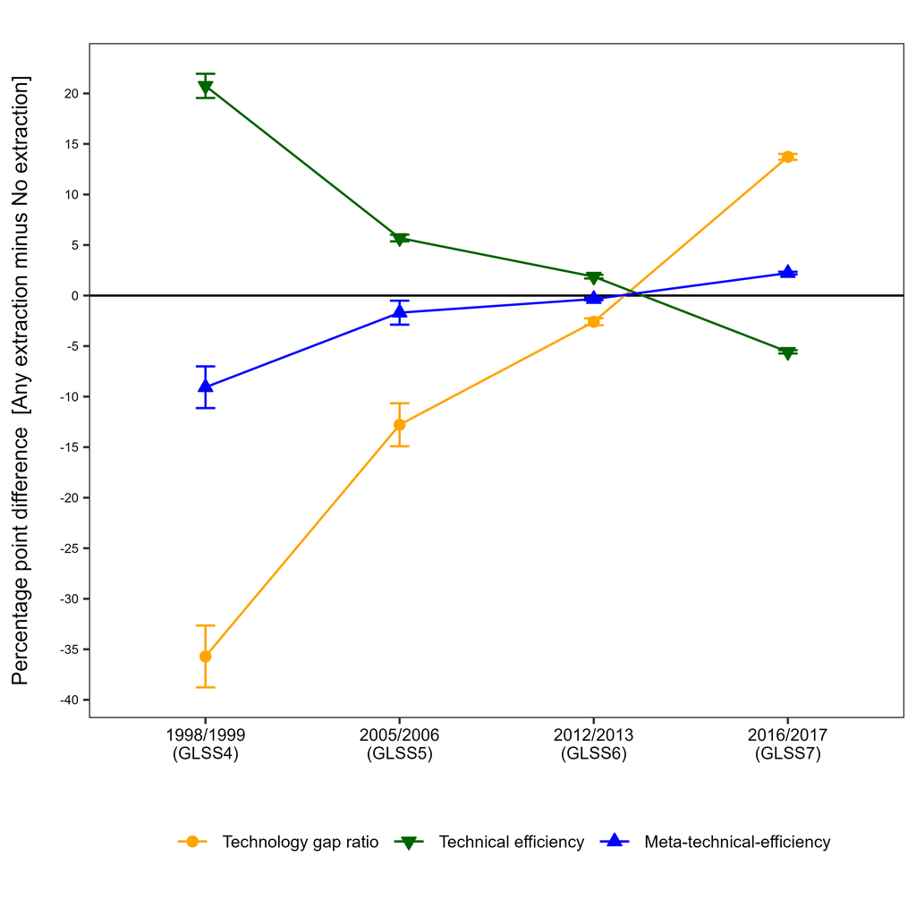

**Figure 2. Crop production technology adoption and technical efficiency gaps associated with natural resource extraction by farmer gender, age, and education in Ghana**

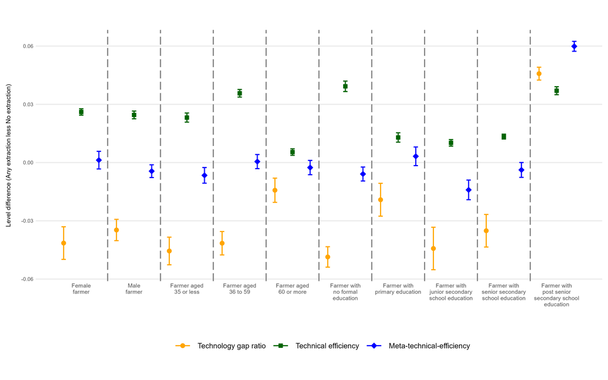

**Figure 3. Crop production technology adoption and technical efficiency gaps associated with natural resource extraction by major crops and administrative regions in Ghana**

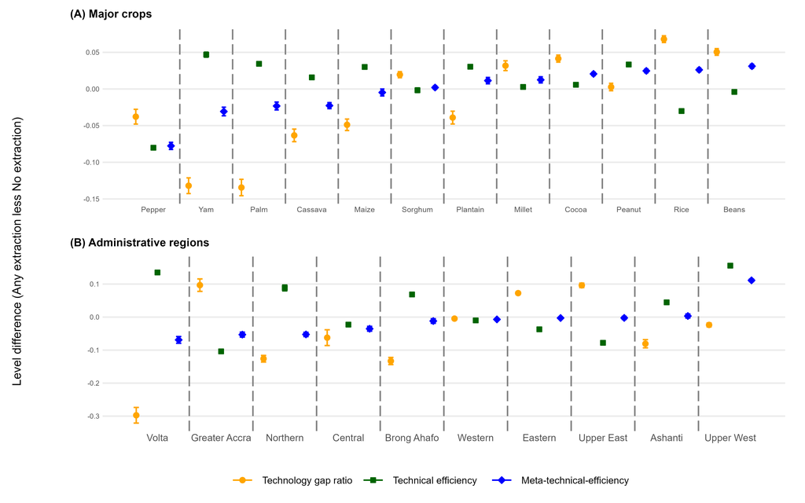